## **ALPA4**

Hoje, sexta-feira, 22 de agosto de 2025, a ação ALPA4 começou a mostrar um desempenho impressionante. Após fechar o dia anterior em R$ 9,02, a ação abriu o dia atual em R$ 9,06 e alcançou um fechamento no valor de R$ 9,45, representando uma variação diária de 4,77%.O que mais chamou atenção foi o momento em que a ação experimentou um destaque notável às 16:15:00s, quando uma quantidade significativa de negociações ocorreu e representou 24,07% do total negociado no dia. Isso contribuiu para uma variação de 2,248% na cotação da ação logo após este ponto.Além disso, é importante notar que a ação ALPA4 tem apresentado um desempenho positivo nos últimos meses e trimestres, com variações mensal e trimestral de 10,4% e 2,16%, respectivamente. No entanto, é preciso considerar que a ação também apresenta uma variação anual mais elevada, de 52,9%.Em resumo, a ação ALPA4 está mostrando um desempenho forte e consistente, com um destaque notável às 16:15:00s. Embora haja variações importantes nos últimos meses e trimestres, é importante considerar o contexto geral da ação e suas tendências antes de tomar qualquer decisão de investimento. Veja a seguir o gráfico do intraday com o destaque do outlier: as setas amarelas destacam o momento e o volume negociado no ponto de outlier. A linha violeta demonstra a tendência do preço antes e depois do destaque.

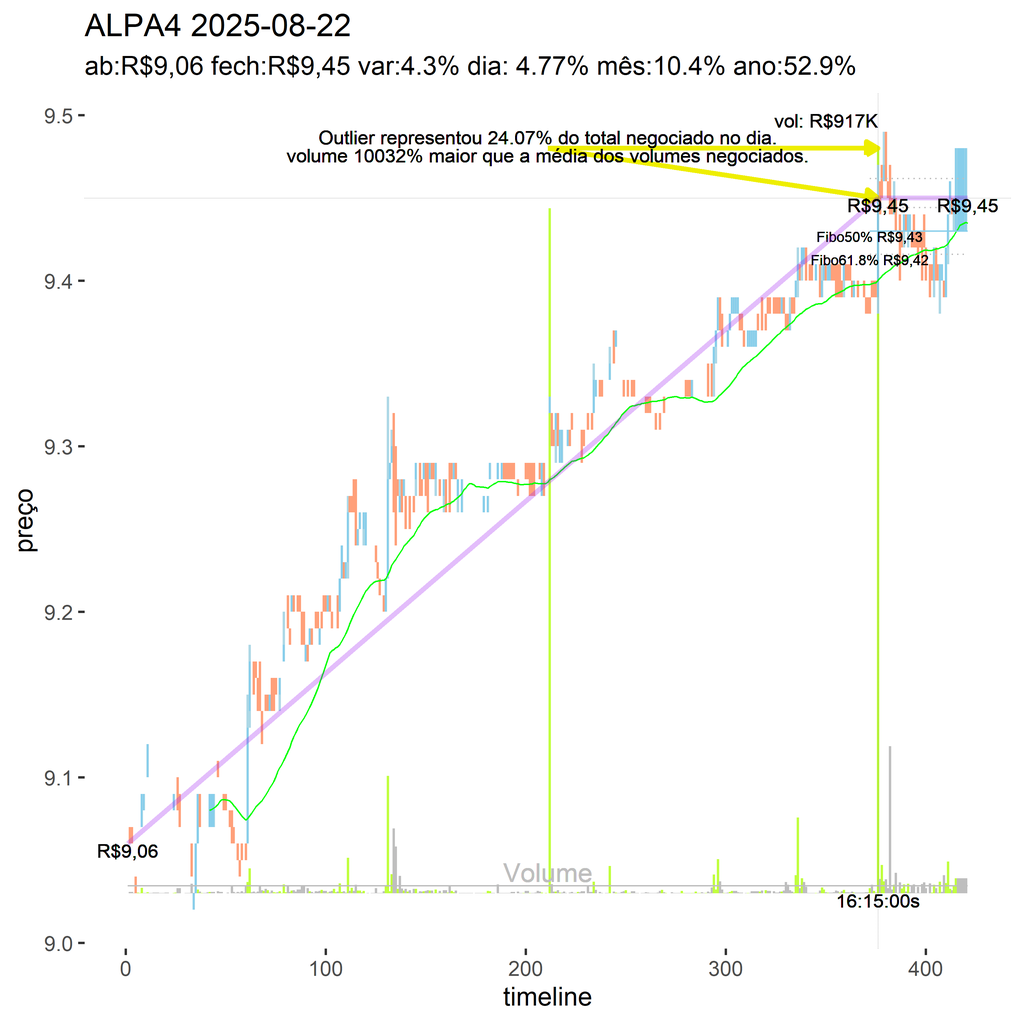

A seguir, desempenho do ativo ao longo do tempo:

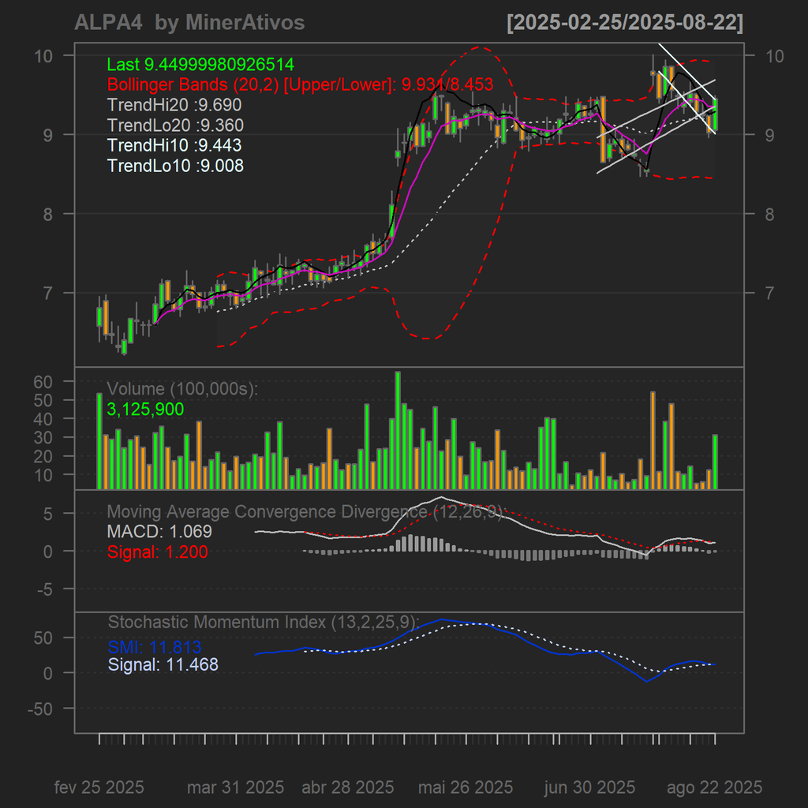

[figure not shown]